# Week 4

```python
def myfun(mylist): # returns the product of second and last element of the list
    return mylist[1]*mylist[-1]
```

```python
myfun([2,3,4,5,6])
```

```
18
```

```python
def myfun(mylist): # returns the product of second and last element of the list
    a = mylist[1]*mylist[-1]
    return a
```

```python
mylist=[[1,2,11],[3,4,7],[5,6,13]]

# want to get [3,5]

print([mylist[1][0],mylist[2][0]])
```

```
[3, 5]
```

## Mutable and non-mutable

```python
a=[1,2,3]
b=a
print(a,b)
a is b # `is` will check if two variables have the same address
```

```
[1, 2, 3] [1, 2, 3]
```

```
True
```

```python
b[0]=4
print(a,b)
```

```
[4, 2, 3] [4, 2, 3]
```

```python
a=3
b=a
# print(a is b)
b=4
print(a,b)
a is b
```

[output not shown]

```
False
```

**mutable** objects (e.g. lists) can be modified without changing their address.

**non-mutable** object (e.g. int,float,strings,booleans,tuples) are copied to a new address when modified

### Tuples

```python
a=(1,2)
print(a)
```

```
(1, 2)
```

```python
a[0]=22
```

```
---------------------------------------------------------------------------
TypeError                                 Traceback (most recent call last)
<ipython-input-18-7845043af3cc> in <module>
----> 1 a[0]=22

TypeError: 'tuple' object does not support item assignment
```

**note** tuples can be returned by functions

```python
def myfun(mylist): # return first and last element of `mylist`
    return mylist[0],mylist[-1]
```

```python
a,b=myfun(['a','b','c','d','e'])
print(a,b)
```

```
a e
```

**note** to make a copy of a list, we can either slice or use the `copy()` method

```python
a=[1,2,3]
b=a # not a separate copy
c=a.copy() # copy
d=a[:] # copy by slicing
a[0]=75
print(a,b,c,d)
```

```
[75, 2, 3] [75, 2, 3] [1, 2, 3] [1, 2, 3]
```

## More on functions: positional, keyword, default argument

Define a function `cvol` that computes the volume of a cylinder

```python
from math import pi
```

```python
def cvol(r,h): # radius and height
    return pi*r*r*h
```

```python
cvol(2,3) # argument by position
```

```
37.69911184307752
```

```python
cvol(3,2) # argument by position
```

```
56.548667764616276
```

```python
cvol(r=3,h=2) # argument by keyword - the order does not matter
```

```
56.548667764616276
```

```python
cvol(h=2,r=3) # argument by keyword
```

```
56.548667764616276
```

```python
def cvol2(r,h=3):
    return pi*r*r*h
```

```python
cvol2(2) # calling h=3 by default
```

```
37.69911184307752
```

```python
cvol2(3,2)
```

```
56.548667764616276
```

```python
def f(a,b,c):
    return (a**b)/c
```

```python
f(2,c=5,b=1)
```

```
0.4
```

**note** arguments without a default value must go before the ones with a default value

**Ex.** build a function `change_n(mystr,n)` that changes the n-th entry of the string `mystr` to `'a'`, or return the original string if too short. If called with only the string argument, it should change the second character to `'a'`

For example `change_n('force')` --> 'farce'

`change_n('force',5)` --> 'forca'

```python
mystr='force'
print(list(mystr))
mystr[1]='a'
```

```
['f', 'o', 'r', 'c', 'e']
```

```
---------------------------------------------------------------------------
TypeError                                 Traceback (most recent call last)
<ipython-input-41-bdc8d825285f> in <module>
      1 mystr='force'
      2 print(list(mystr))
----> 3 mystr[1]='a'

TypeError: 'str' object does not support item assignment
```

Let's move on discord until 12:35

max 4 persons per room

room 10 - quiet room (no max students limit)

```python
def change_n(mystr,n=2):
    if len(mystr)<n or n<=0: # string too short or n<=0
        return mystr
    mylist=list(mystr)
    mylist[n-1]='a' # changing the n-th element to 'a'
    tmp='' # empty string
    for k in mylist:
        tmp+=k
    return tmp
```

```python
change_n('force',25)
```

```
'force'
```

```python
change_n('force',5)
```

```
'forca'
```

```python
change_n('force')
```

```
'farce'
```

```python
def change_n(mystr,n=2): # string slicing
    if len(mystr)<n or n<=0: # string too short or n<=0
        return mystr
    return mystr[:n-1]+'a'+mystr[n:]
```

```python
change_n('corce')
```

```
'carce'
```

```python
change_n('corce',4)
```

```
'corae'
```

## List comprehension

build a list of the half of the first 10 integers [0,0.5,1,1.5,....]

```python
mylist=[]
for k in range(10):
    mylist.append(k/2)
print(mylist)
```

```
[0.0, 0.5, 1.0, 1.5, 2.0, 2.5, 3.0, 3.5, 4.0, 4.5]
```

more concise alternative

```python
mylist=[k/2 for k in range(10)] # list comprehension
print(mylist)
```

```
[0.0, 0.5, 1.0, 1.5, 2.0, 2.5, 3.0, 3.5, 4.0, 4.5]
```

We can make more elaborate examples

```python
mylist=[greeting+' deEar '+name for greeting in ['Hi','bye'] for name in ['Simone','Lucia','Rosella'] ]
```

```python
print(mylist)
```

[output not shown]

Let's try to do the same with for loops

```python
mylist=[]
for greeting in ['hi','bye']:
    for name in ['Simone','Lucia','Rosella']:
        mylist.append(greeting+' dear '+name)
print(mylist)
```

```
['hi dear Simone', 'hi dear Lucia', 'hi dear Rosella', 'bye dear Simone', 'bye dear Lucia', 'bye dear Rosella']
```

`if`

```python
myl=[k**2 for k in range(12) if k%2==0] # build a list of  squares of even numbers less than 12
print(myl)
```

```
[0, 4, 16, 36, 64, 100]
```

```python
myl=[]
for k in range(12):
    if k%2==0:
        myl.append(k**2)
print(myl)
```

```
[0, 4, 16, 36, 64, 100]
```

**Note** on Quiz 4, Q5

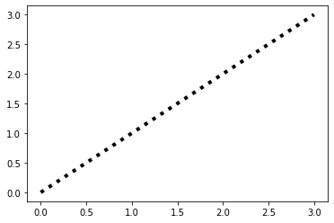

```python
import matplotlib.pyplot as plt
x=range(4) # 4 elements
#y=range(3) # 3 elements - not correct
y=range(4) # fix
plt.plot(x,y,'k:',linewidth=4)
plt.show()
```

```python
def cubicroot(n): # returns the cubic root of n
    return pow(n,1/3)
```

```python
cubicroot(8)
```

```
2.0
```

Want to build a list, containing the cubic root of all integers from -20 to 20 included

```python
mylist=[cubicroot(k) for k in range(-20,21)]
print(mylist)
```

[output not shown]

**Ex.** plot $x^3-2x+1$ in [0,1] (using 'a lot of steps'[say at least 100])

- build `xcoord` list
- build `ycoord` list

```python
n=10 # number of steps
xcoord=[x/n for x in range(n+1)] # step-wise description of [0,1] with n equal steps
print(xcoord)
```

```
[0.0, 0.1, 0.2, 0.3, 0.4, 0.5, 0.6, 0.7, 0.8, 0.9, 1.0]
```

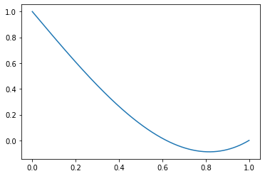

```python
n=1000
xcoord=[x/n for x in range(n+1)] # step-wise description of [0,1] with n equal steps
ycoord=[x**3 - 2*x + 1 for x in xcoord]

plt.plot(xcoord,ycoord)
plt.show()
#print(ycoord)
```

**Ex.** plot the graph of the circle with radius 2 centered at the origin

Once you have the plot (use at least 100 steps)

1. put your name as the plot title
2. upload on discord in the channel - circle

to keep the same scale use `plt.axis('equal')`

# Project 2

## step 1:

1. find a way to generate k areas (using the p-series) (say k=100,p=2)
2. find a way to generate the corresponding radii
3. find area of black circle (for a p-series we need the $\zeta$ function `from scipy.special import zetac`

$\sum_{n=1}^\infty \dfrac{1}{n^p}=1+\dfrac{1}{4}+\dfrac{1}{9}+\ldots=A_1+A_2+A_3+\ldots$

```python
from math import pi, sqrt
k=100
p=2
A=[(1/n**p) for n in range(1,k+1)] # list of the areas of the small circles
r=[sqrt(a/pi) for a in A] # list of radii of small circles
```

```python
print(A[:3])
```

```
[1.0, 0.25, 0.1111111111111111]
```

```python
print(r[:3])
```

```
[0.5641895835477563, 0.28209479177387814, 0.18806319451591877]
```

```python
from scipy.special import zetac


zetac(2) # this sums the term from 2 to infty
```

```
0.6449340668482264
```

```python
A_bc=1+zetac(2) # area of big circle for p=2 corresponding to the sum of the series
print(A_bc)
```

```
1.6449340668482264
```

**Ex.** build a function `find_radii_p(k,p)` that will compute (and return) the radii of the first k small circles and the radius of the big circle for the p-series

**Ex.** build a function `find_radii_g(k,p)` that will compute (and return) the radii of the first k small circles and the radius of the big circle for the geometric series